# analise_cpu

# Análises

Para os casos em que notamos outliers, talvez fosse mais apropriado utilizar a mediana como medida estatística ao invés da média, tendo em vista que aquela é uma medida robusta, isto é, não é afetada por outliers, enquanto que está é. Além disso, como o desvio padrão e a variância fazendo uso da média e levam em conta todos outliers, temos que eles também serão bastante afetados pela presença desses valores.

## Análise para operação do log1CPU:

Notamos que, no gráfico referente ao log1CPU, existem indícios de alguns outliers, como na leitura 55 (cujo valor é 19.31%), pois ela se distanciou muito das demais em termos de diferença em %. Vamos fazer uma visualização de um box-plot para essa medição de modo a constarmos se, de fato, existem outliers.

[figure not shown]

### Conclusão

Nossa asserção sobre a existência de outliers estava correta e foi confirmada pelo boxplot acima. Contudo, existem, ao todo, 2 outliers.

## Análise para operação de log2CPU:

Notamos que, no gráfico referente ao log2CPU, existem indícios de alguns outliers, novamente na leitura 55, pois ela se distanciou de maneira singular com relação às demais em termos de diferença em %. Vamos fazer uma visualização de um box-plot para essa medição de modo a constarmos se, de fato, existe algum outlier.

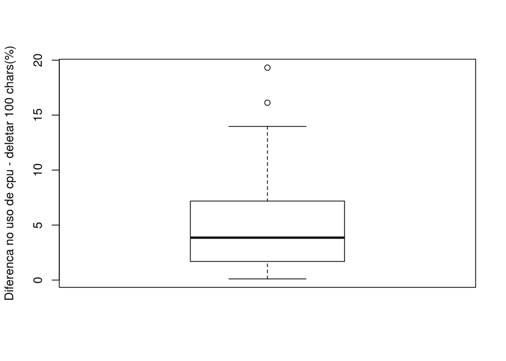

### Conclusão

De fato, nossa hipótese sobre a presença de outlier estava correta e foi confirmada pelo boxplot acima. Novamente encontramos 2 outliers.

## Análise para operação log3CPU:

Notamos que, no gráfico referente ao log3CPU, existe indicios de haver um outlier. Vamos fazer uma visualização de um box-plot para essa medição de modo a constarmos se, de fato, existe algum outlier.

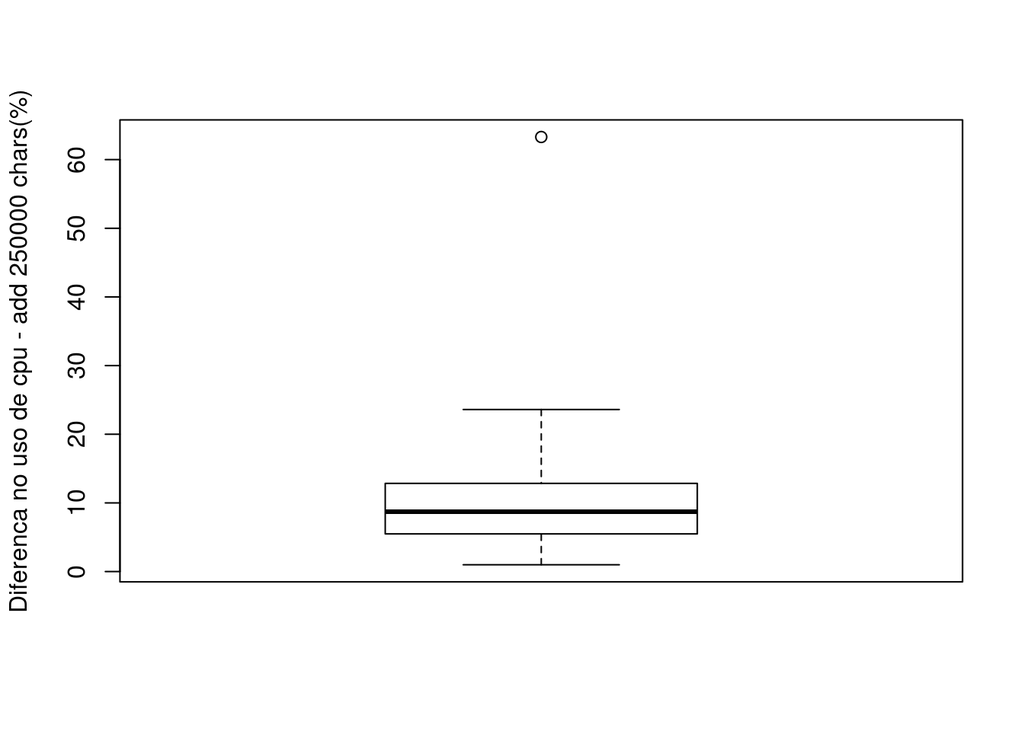

### Conclusão

De fato, nossa hipótese sobre a presença de outlier estava correta e foi confirmada pelo boxplot acima, pois notamos a existência de apenas 1 outlier.

## Análise para operação log4CPU:

Novamente notamos o indicio de um outlier na mediçaõ, dessa vez na medição 35. Para validarmos nossa hipótese, vamos fazer uma visualização de um box-plot para essa medição de modo a constarmos se, de fato, não existe algum outlier.

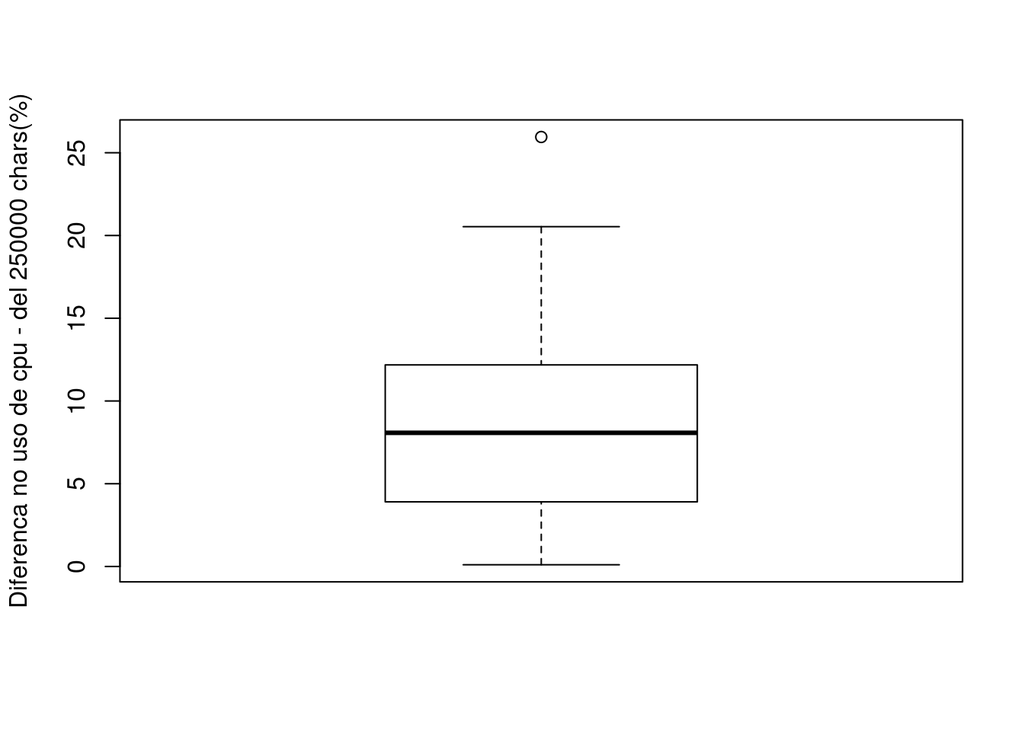

### Conclusão

De fato, nossa hipótese sobre a presença de outlier estava correta e foi confirmada pelo boxplot acima.

## Análise para operação log5CPU:

Notamos que, no gráfico referente ao log5CPU, existem indícios de alguns outliers, como na leitura 35(~26%), pois ela se distancia de maneira singular com relação às demais em termos de diferença em %. Vamos fazer uma visualização de um box-plot para essa medição de modo a constarmos se, de fato, existe algum outlier.

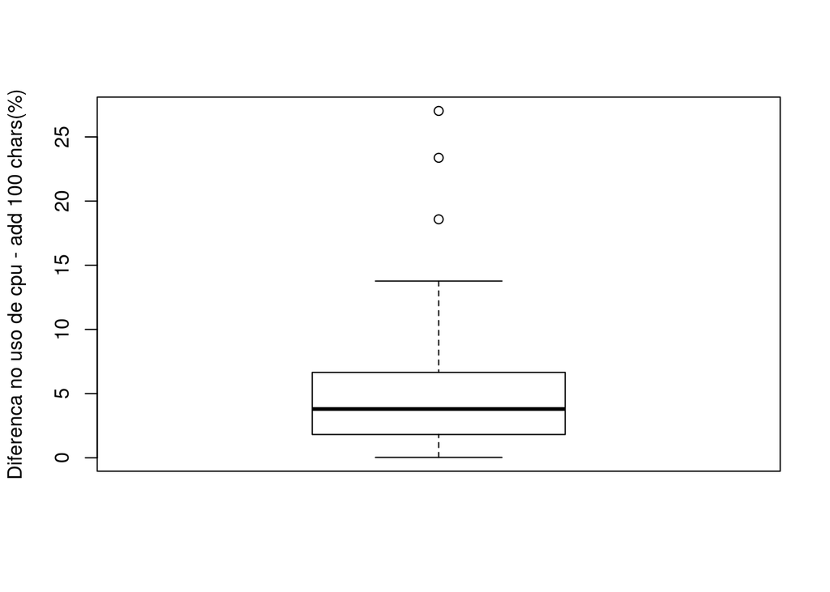

## Conclusão

Além do outlier citado, existem mais 2 outliers na medição, totalizando 3 no total.

## Análise para operação log6CPU:

Não notamos no gráfico referente ao log6CPU quaisquer indícios de existência de outliers. Para validarmos nossa hipótese, vamos fazer uma visualização de um box-plot para essa medição de modo a constarmos se, de fato, não existe algum outlier.

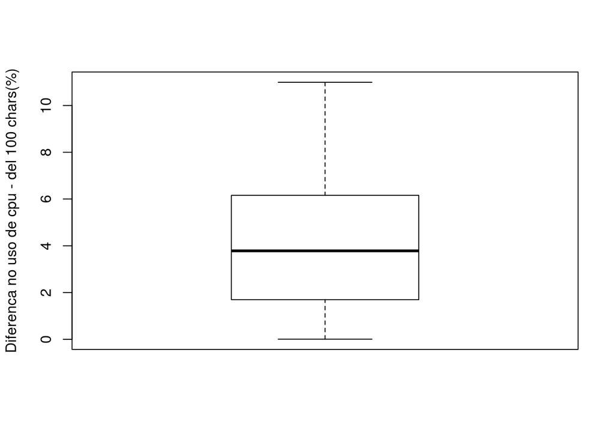

## Conclusão

Podemos concluir que nossa hipótese sobre inexistência de outliers para essa medição estava correta e foi confirmada pelo boxplot acima.

## Análise para operação log7CPU:

Notamos que, no gráfico referente ao log7CPU, existem indícios de alguns outliers, como na leitura 55 e 41, pois elas se distanciaram com relação às demais em termos de diferença em %. Vamos fazer uma visualização de um box-plot para essa medição de modo a constarmos se, de fato, existe algum outlier.

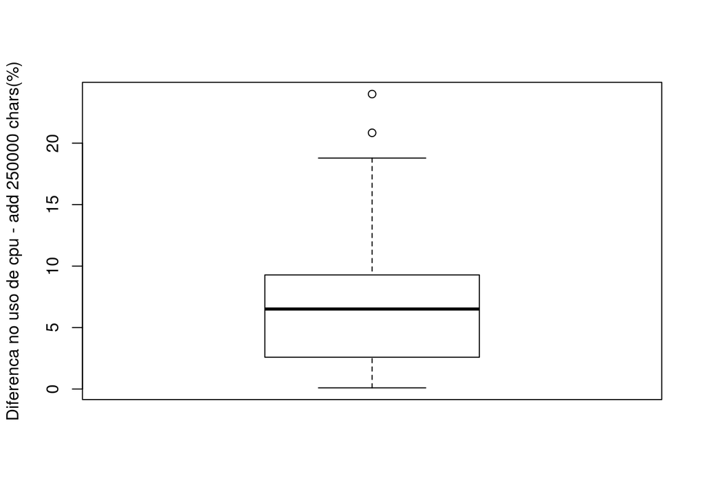

## Conclusão

De fato, nossa hipótese sobre a presença de outlier estava correta e foi confirmada pelo boxplot acima. Foram identificados 2 outliers.

## Análise para operação log8CPU:

Novamente notamos o indicio de um outlier na mediçaõ, dessa vez na medição 39. Para validarmos nossa hipótese, vamos fazer uma visualização de um box-plot para essa medição de modo a constarmos se, de fato, existe algum outlier.

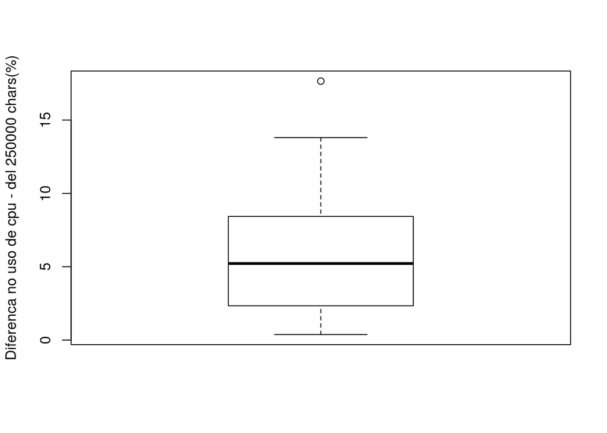

## Conclusão

De fato, nossa hipótese sobre a presença de outlier estava correta e foi confirmada pelo boxplot acima.

# Analise geral e conclusões finais

Apesar de existirem poucos outliers, eles contriuem muito para o resultado final do coeficiente de variação calculado. Dificultando assim a analise. Com isso foi utilizado um função para remover os outliers de nossos dados. Mesmo assim a variação das amostras é muito grande. Logo, para todos os casos, a média não é tão representativa. Por isso, a mediana, nesse caso, pode ser uma medida mais precisa do que a média. Essa dispersão pode ser causada por diversos fatores, uma delas é como o java lida com o heap_size, como o java lida com o garbage collection, como o SO lida com os processos continuos, etc.

# Anexo I

Abaixo veremos a média, mediana, e desvio padrão, além do intervalo de confiança(i.c.) com 95% de confiança(alfa = 0,05) para os dados das medições realizadas. Também vamos avaliar o grau de representatividade da média através do coeficiente de variação(cv), que também serve para nos indicar a homogeneidade (se os valores estão ao redor da média), a precisão dos dados e a variabilidade com relação à média (quanto o conjunto se afasta da média). Como resultado direto, temos que quanto menor o c.v., maior a homogeneidade e a precisão do conjunto de dados. Além disso, se o valor do cv for menor que 50%, então a média é dita representativa; não, caso contrário.

## Medidas estatísticas para log1CPU

```
## [1] "o valor da média para as distâncias para o log1CPU é: 4.562753"
```

```
## [1] "o valor da mediana para as distâncias para o log1CPU é: 3.721432"
```

```
## [1] "o valor da variância para as distâncias para o log1CPU é: 12.118134"
```

```
## [1] "o valor do desvio padrão para as distâncias para o log1CPU é: 3.481111"
```

```
## [1] "o valor do coeficiente de variação para as distâncias para o log1CPU é: 76.294089%"
```

```
## [1] "Com 95% de confiança, o intervalo que compreende o verdadeiro valor da média está entre 3.681927 e 5.443580."
```

# Medidas estatísticas para log2CPU

```
## [1] "o valor da média para as distâncias log2CPU é: 4.562753"
```

```
## [1] "o valor da mediana para as distâncias log2CPU é: 3.721432"
```

```
## [1] "o valor da variância para as distâncias log2CPU é: 12.118134"
```

```
## [1] "o valor do desvio padrão para as distâncias log2CPU é: 3.481111"
```

```
## [1] "o valor do coeficiente de variação para as distâncias log2CPU é: 76.294089%"
```

```
## [1] "Com 95% de confiança, o intervalo que compreende o verdadeiro valor da média está entre 3.681927 e 5.443580."
```

## Medidas estatísticas para log3CPU

```
## [1] "o valor da média para as distâncias log3CPU é: 9.165524"
```

```
## [1] "o valor da mediana para as distâncias log3CPU é: 8.203635"
```

```
## [1] "o valor da variância para as distâncias log3CPU é: 26.300533"
```

```
## [1] "o valor do desvio padrão para as distâncias log3CPU é: 5.128405"
```

```
## [1] "o valor do coeficiente de variação para as distâncias log3CPU é: 55.953206%"
```

```
## [1] "Com 95% de confiança, o intervalo que compreende o verdadeiro valor da média está entre 7.867883 e 10.463166."
```

# Medidas estatísticas para log4CPU

```
## [1] "o valor da média para as distâncias log4CPU é: 8.434081"
```

```
## [1] "o valor da mediana para as distâncias log4CPU é: 8.020955"
```

```
## [1] "o valor da variância para as distâncias log4CPU é: 28.191743"
```

```
## [1] "o valor do desvio padrão para as distâncias log4CPU é: 5.309590"
```

```
## [1] "o valor do coeficiente de variação para as distâncias log4CPU é: 62.953980%"
```

```
## [1] "Com 95% de confiança, o intervalo que compreende o verdadeiro valor da média está entre 7.090594 e 9.777568."
```

## Medidas estatísticas para log5CPU

```
## [1] "o valor da média para as distâncias para o log5CPU é: 4.174663"
```

```
## [1] "o valor da mediana para as distâncias para o log5CPU é: 3.303785"
```

```
## [1] "o valor da variância para as distâncias para o log5CPU é: 11.296817"
```

```
## [1] "o valor do desvio padrão para as distâncias para o log5CPU é: 3.361074"
```

```
## [1] "o valor do coeficiente de variação para as distâncias para o log5CPU é: 80.511266%"
```

```
## [1] "Com 95% de confiança, o intervalo que compreende o verdadeiro valor da média está entre 3.324209 e 5.025116."
```

# Medidas estatísticas para log6CPU

```
## [1] "o valor da média para as distâncias log6CPU é: 4.015044"
```

```
## [1] "o valor da mediana para as distâncias log6CPU é: 3.783995"
```

```
## [1] "o valor da variância para as distâncias log6CPU é: 8.166596"
```

```
## [1] "o valor do desvio padrão para as distâncias log6CPU é: 2.857726"
```

```
## [1] "o valor do coeficiente de variação para as distâncias log6CPU é: 71.175445%"
```

```
## [1] "Com 95% de confiança, o intervalo que compreende o verdadeiro valor da média está entre 3.291953 e 4.738135."
```

## Medidas estatísticas para log7CPU

```
## [1] "o valor da média para as distâncias para o log7CPU é: 6.297910"
```

```
## [1] "o valor da mediana para as distâncias para o log7CPU é: 6.293048"
```

```
## [1] "o valor da variância para as distâncias para o log7CPU é: 19.305386"
```

```
## [1] "o valor do desvio padrão para as distâncias para o log7CPU é: 4.393789"
```

```
## [1] "o valor do coeficiente de variação para as distâncias para o log7CPU é: 69.765829%"
```

```
## [1] "Com 95% de confiança, o intervalo que compreende o verdadeiro valor da média está entre 5.186149 e 7.409672."
```

# Medidas estatísticas para log8CPU

```
## [1] "o valor da média para as distâncias log8CPU é: 5.687402"
```

```
## [1] "o valor da mediana para as distâncias log8CPU é: 5.193290"
```

```
## [1] "o valor da variância para as distâncias log8CPU é: 14.373925"
```

```
## [1] "o valor do desvio padrão para as distâncias log8CPU é: 3.791296"
```

```
## [1] "o valor do coeficiente de variação para as distâncias log8CPU é: 66.661297%"
```

```
## [1] "Com 95% de confiança, o intervalo que compreende o verdadeiro valor da média está entre 4.728089 e 6.646715."
```

# Anexo II

## Variações

```r
mat
```

```
##   a     b     c    d     e     f     g     h
## a 0     0     4.48 4.3   -0.42 0.06  2.57  1.47
## b 0     0     4.48 4.3   -0.42 0.06  2.57  1.47
## c -4.48 -4.48 0    -0.18 -4.9  -4.42 -1.91 -3.01
## d -4.3  -4.3  0.18 0     -4.72 -4.24 -1.73 -2.83
## e 0.42  0.42  4.9  4.72  0     0.48  2.99  1.89
## f -0.06 -0.06 4.42 4.24  -0.48 0     2.51  1.41
## g -2.57 -2.57 1.91 1.73  -2.99 -2.51 0     -1.1
## h -1.47 -1.47 3.01 2.83  -1.89 -1.41 1.1   0
```

```r
names
```

```
## [1] "a = Poucos usuarios, add, poucos caracteres"
## [2] "b = Poucos usuarios, del, poucos caracteres"
## [3] "c = Poucos usuarios, add, muitos caracteres"
## [4] "d = Poucos usuarios, del, muitos caracteres"
## [5] "e = Muitos usuarios, add, poucos caracteres"
## [6] "f = Muitos usuarios, del, poucos caracteres"
## [7] "g = Muitos usuarios, add, muitos caracteres"
## [8] "h = Muitos usuarios, del, muitos caracteres"
```